# Projecting cortical neurons across technologies with SWNE

Yan Wu

8/10/2018

This is a quick walkthrough demonstrating how to project new scRNA-seq data onto an existing SWNE embedding. We’ll be using a human cortical neuron dataset generated using the snDropSeq technology as our training dataset. The pre-computed snDropSeq Seurat object can be found here. We’ll be projecting data generated using a much older technology, the C1 microfluidic platform. The C1 data contains the same cortical neuron cell types, but from a different patient (and obviously a different scRNA-seq technology). The pre-computed C1 Seurat object can be found here

Load the required libraries

```r
library(Seurat)
library(swne)
```

First, we’ll be constructing an SWNE embedding for the snDropSeq training data

Load the snDropSeq training data, normalize the counts matrix, and extract the overdispersed genes

```r
train.obj <- readRDS("~/swne/Data/snDropSeq_cortical_neurons.Robj")
train.norm.counts <- ExtractNormCounts(train.obj, obj.type = "seurat", rescale = T)
```

```
## calculating variance fit ... using gam
```

```r
var.genes <- train.obj@var.genes
```

Extract training data cell types

```r
train.clusters <- train.obj@ident
names(train.clusters) <- train.obj@cell.names
```

Find the optimal number of factors

```
## [1] "Warning: This function can be slow for very large datasets"
```

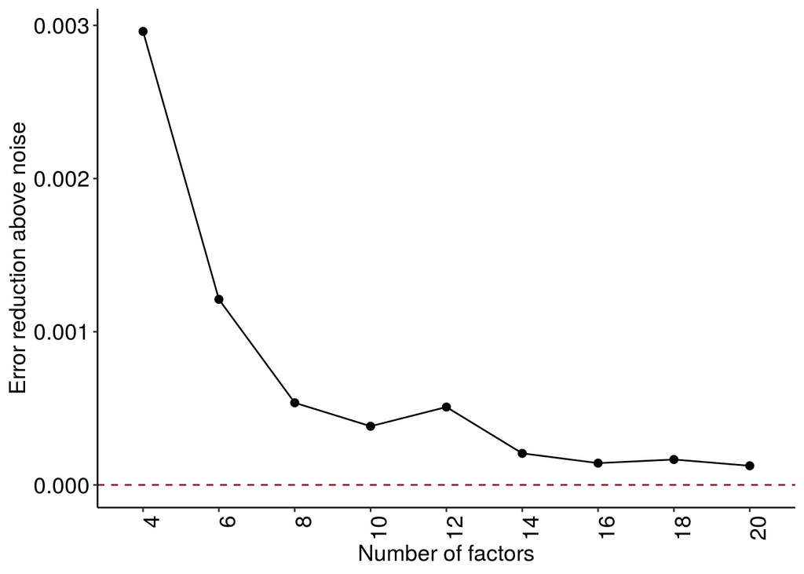

```r
k.range <- seq(2,20,2)
n.cores <- 24

k.err <- FindNumFactors(train.norm.counts[var.genes,], k.range = k.range, n.cores = n.cores, do.plot = T,
                        seed = 223464)
```

Run NMF using the optimal number of factors and project features

```r
k <- 16
train.nmf.res <- RunNMF(train.norm.counts[var.genes,], k = k, init = "ica", n.cores = n.cores, ica.fast = T)
train.nmf.res$W <- ProjectFeatures(train.norm.counts, train.nmf.res$H, n.cores = n.cores)
train.nmf.scores <- train.nmf.res$H
```

Run SWNE embedding and hide the factors

```r
train.embedding <- EmbedSWNE(train.nmf.scores, train.obj@snn, alpha.exp = 1.25, snn.exp = 0.25,
                             n_pull = 3, dist.use = "cosine")
```

```
## Initial stress        : 0.34118
## stress after  10 iters: 0.11766, magic = 0.461
## stress after  20 iters: 0.10616, magic = 0.500
## stress after  30 iters: 0.10406, magic = 0.500
## stress after  40 iters: 0.10353, magic = 0.500
## stress after  50 iters: 0.10321, magic = 0.500
## stress after  60 iters: 0.10301, magic = 0.500
## stress after  70 iters: 0.10294, magic = 0.500
```

```r
train.embedding$H.coords$name <- "" ## Hide factors
```

Embed key neuronal markers

```r
genes.embed <- c("CBLN2", "NRGN", "GRIK1", "NTNG1", "DAB1", "DCC", "POSTN")
train.embedding <- EmbedFeatures(train.embedding, train.nmf.res$W, genes.embed, n_pull = 3, scale.cols = F)
```

Make SWNE plot of training data

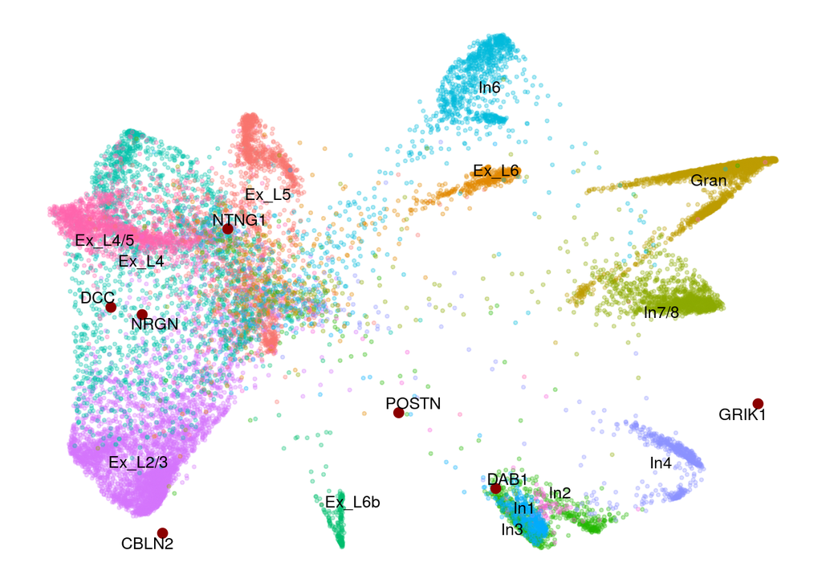

```r
plot.seed <- 124532
PlotSWNE(train.embedding, alpha.plot = 0.3, sample.groups = train.clusters, do.label = T,
         label.size = 3.5, pt.size = 0.75, show.legend = F, seed = plot.seed)
```

Now we can project the C1 test datset. First let’s load the Seurat object.

```r
test.obj <- readRDS("~/swne/Data/C1_cortical_neurons.Robj")
test.norm.counts <- ExtractNormCounts(test.obj, obj.type = "seurat", rescale = T, rescale.method = "log")
```

```
## calculating variance fit ... using gam
```

Extract the test dataset cell types

```r
test.clusters <- test.obj@ident
names(test.clusters) <- test.obj@cell.names; levels(test.clusters);
```

```
##  [1] "Ex1" "Ex2" "Ex3" "Ex4" "Ex5" "Ex6" "Ex7" "Ex8" "In1" "In2" "In3"
## [12] "In4" "In5" "In6" "In7" "In8"
```

Match the test dataset cell types to the training dataset cell types

```r
test.clusters <- plyr::revalue(test.clusters, replace =
                                 c("Ex1" = "Ex_L2/3", "Ex2" = "Ex_L4", "Ex3" = "Ex_L4",
                                   "Ex4" = "Ex_L4/5", "Ex5" = "Ex_L5", "Ex6" = "Ex_L6",
                                   "Ex7" = "Ex_L6", "Ex8" = "Ex_L6b",
                                   "In7" = "In7/8", "In8" = "In7/8"))
```

Project the test gene expression matrix onto the training dataset NMFs

```r
genes.project <- intersect(var.genes, rownames(test.norm.counts))
test.nmf.scores <- ProjectSamples(test.norm.counts, train.nmf.res$W, features.use = genes.project, n.cores = n.cores)
```

Project the test data onto the training SNN

```r
test.snn <- ProjectSNN(test.norm.counts, train.norm.counts, n.pcs = 30, features.use = genes.project, k = 20,
                       print.output = F)
```

```
## [1] "Running PCA and test data projection"
```

```r
test.embedding <- ProjectSWNE(train.embedding, test.nmf.scores, SNN = test.snn,
                              alpha.exp = 1.25, snn.exp = 0.25, n_pull = 3)
```

Make sure we’re using the same cluster colors

```r
cluster.colors <- ExtractSWNEColors(train.embedding, train.clusters, seed = plot.seed)
cluster.colors <- cluster.colors[grepl("Ex|In", names(cluster.colors))]
cluster.colors[["In5"]] <- "#00BFFF"
```

Plot the test data projected onto the training SWNE embedding. Note how the test data cell types map onto the same spatial locations as the corresponding training data cell types

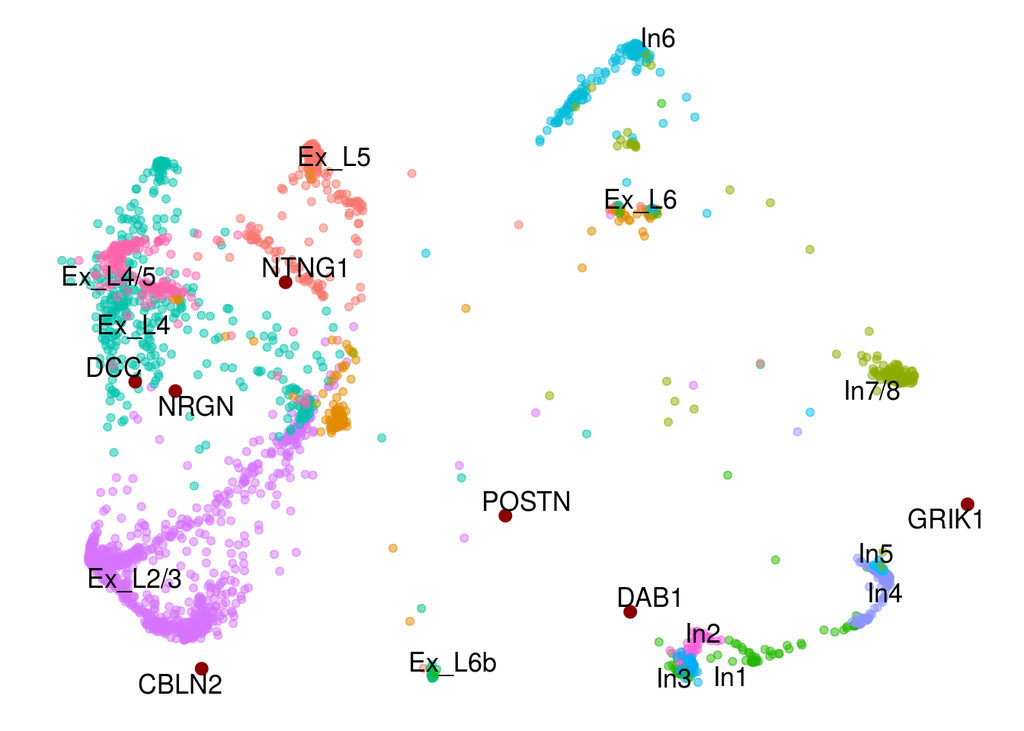

```r
PlotSWNE(test.embedding, alpha.plot = 0.5, sample.groups = test.clusters, do.label = T,
         pt.size = 1.5, show.legend = F, seed = plot.seed) +
  scale_color_manual(values = cluster.colors)
```